# The APM Webapp

30 July 2017

## Introduction of the APM

The APM webapp enables you to analyze the daily air polution patterns at three measuring stations (exploited by an organization called "RIVM"), located in the Hague (the Netherlands). The three locations are Amsterdamse Veerkade, Bleriotlaan en Rebecquestraat. The data for this research is retreived from https://www.luchtmeetnet.nl/download.

The user of the Webapp can select a specific polutant and weekday. The Webapp will then calculate the averaged polution levels in ug/m3 over all measurements taken during the period 2015-2016 for that given polutant and weekday. The resulting plot shows the daily polution pattern, using hourly levels and a loess smoother.

All data and coding is available at [Github](https://github.com/GVersteeg/DDP_Wk4_PGA).

## Data Processing

The data for this research is retrieved in the form of a csv-file with measurements for each of the stations. These csv-files are merged into one dataframe.

```
Classes 'tbl_df', 'tbl' and 'data.frame':   18378 obs. of  5 variables:
 $ tijdstip : chr  "2015-08-01 02:00:00+02:00" "2015-08-01 02:00:00+02:00" "2015-08-01 03:00:00+02:00" "2015-08-01 03:00:00+02:00" ...
 $ locatie  : chr  "Den Haag-Amsterdamse Veerkade" "Den Haag-Amsterdamse Veerkade" "Den Haag-Amsterdamse Veerkade" "Den Haag-Amsterdamse Veerkade" ...
 $ component: chr  "NO" "NO2" "NO" "NO2" ...
 $ waarde   : num  2.88 26.78 4.76 25.42 3.26 ...
 $ LKI      : int  1 3 1 3 1 3 3 1 1 3 ...
```

## Processing the data

The data is pre-processed in such a fashion that the resulting dataframe can easily be used by the Webapp for calculating the averaged polution levels during a certain weekday.

```
# A tibble: 18,378 x 6
         date      time  weekday              station polutant ug_m3
       <date> <S3: hms>    <chr>               <fctr>   <fctr> <dbl>
1  2015-08-01  00:00:00 Saturday Amsterdamse Veerkade       NO  2.88
2  2015-08-01  00:00:00 Saturday Amsterdamse Veerkade      NO2 26.78
3  2015-08-01  01:00:00 Saturday Amsterdamse Veerkade       NO  4.76
4  2015-08-01  01:00:00 Saturday Amsterdamse Veerkade      NO2 25.42
5  2015-08-01  02:00:00 Saturday Amsterdamse Veerkade       NO  3.26
6  2015-08-01  02:00:00 Saturday Amsterdamse Veerkade      NO2 26.51
7  2015-08-01  03:00:00 Saturday Amsterdamse Veerkade      NO2 26.46
8  2015-08-01  03:00:00 Saturday Amsterdamse Veerkade       NO  3.16
9  2015-08-01  04:00:00 Saturday Amsterdamse Veerkade       NO  3.28
10 2015-08-01  04:00:00 Saturday Amsterdamse Veerkade      NO2 25.19
# ... with 18,368 more rows
```

## Example plot (NO2, average Monday)

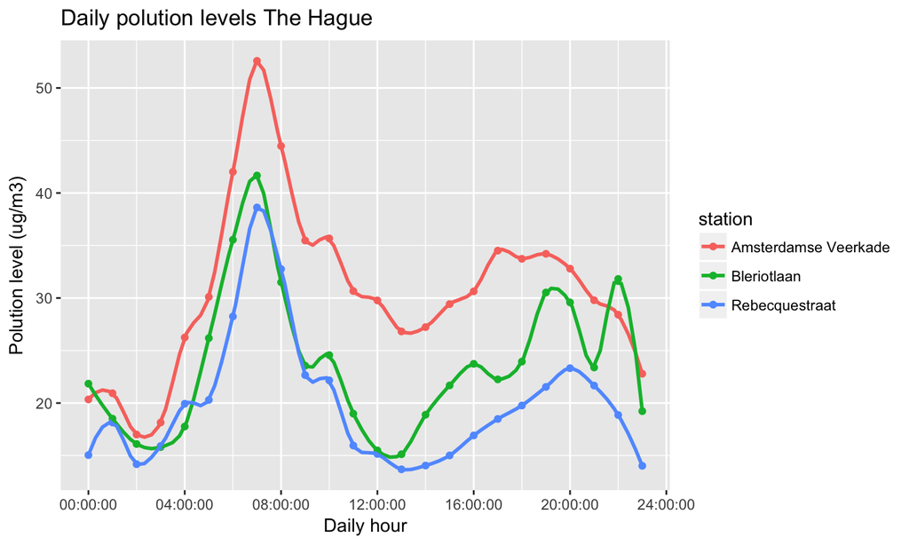